# Assignment Three

Krutika Joshi

# Introduction

This study is based on the data set collected from GSE212591. The study focused on the efficacy of azacitidine and decitabine treatments for infant acute lymphoblastic leukemia (ALL). The data handling involved removing duplicates and unmapped genes and was followed by normalization using the Trimmed Mean of M-values (TMM). This was completed to ensure the data set can be compared across different library sizes and treatment conditions.

Using the normalized data, multidimensional scaling (MDS) and dispersion analysis was applied to assess the differential gene expression. MDS provided a visual representation of the treatment effects and showed different clustering of samples based on treatment type. The results showed significant differences in gene expression patterns among azacitidine and decitabine treatments. To elaborate more on the analysis, dispersion analysis further highlighted the variability in gene expression. There was a notably high differentially expressed genes in decitabine-treated samples compared to controls and azacitidine treatments. This suggested that using both decitabine and azacitidine may be helpful in treating ALL.

# Downloads

```r
options(repos = c(CRAN = "https://cran.rstudio.com/"))
install.packages("GSA")
if (!requireNamespace("circlize", quietly = TRUE))
    install.packages("circlize")
library(circlize)
if (!requireNamespace("BiocManager", quietly = TRUE))
    install.packages("BiocManager")
library(BiocManager)
BiocManager::install("edgeR")
```

```r
BiocManager::install("ComplexHeatmap")
BiocManager::install("gprofiler2")
library(edgeR)
library(gprofiler2)
library(ComplexHeatmap)

if (!requireNamespace("GEOquery", quietly = TRUE))
    BiocManager::install("GEOquery")
library(GEOquery)
```

# Breif Overview of A1: Introduction

As part of the first assignment, I examined gene expression data from a dataset called GSE212591, describing the preclinical efficacy of azacitidine and venetoclax treatments against infants with acute lymphoblastic leukemia (ALL) rearranged in the KMT2A gene. Despite being rare, this form of leukemia is aggressive, with high mortality rates and no established prognosis in infants. Three different samples undergoing treatment with either azacitidine or decitabine are examined in the dataset across multiple cell lines to assess the effects of the treatment. A variety of analyses were conducted to understand the treatment’s impact on the dataset, including data cleaning, normalization, and various visual and statistical assessments.

The data handling section ensured that no duplicates or unmapped genes were present in the dataset. This was followed by using counts per million (CPM) to encompass different library depths. Following that, to normalize the data, the TMM (Trimmed Mean of M-values) normalization method was used. To view the differences in the dataset before and after applying TMM and CPM, a box plot was used to visualize the differences. There seemed to be a mild difference in the spread of the dataset, but essentially, the datasets were almost identical before and after cleaning, as this was expected since the authors of the study had already cleaned it.

Compared to the control samples, azacitidine and decitabine treatment differentially induced gene expression. Decitabine’s expression profile differed markedly from the control and azacitidine-treated samples based on multidimensional scaling (MDS) and dispersion analysis. The MDS showed evident clustering of the data set based on treatment which will be further explored in A2. Results from A1 showed that azacitidine and decitabine can modulate gene expression in KMT2A-rearranged ALL, offering the possibility of using azacitidine and decitabine for treatment. These treatments need to be studied further which is what will be explored in A2.

# Downloading important packages

```r
# Installing and loading important packages
if (!requireNamespace("BiocManager", quietly = TRUE))
    install.packages("BiocManager")
library(BiocManager)
library(gprofiler2)
library(ComplexHeatmap)

if (!requireNamespace("GEOquery", quietly = TRUE))
    BiocManager::install("GEOquery")
library(GEOquery)

if (!requireNamespace("knitr", quietly = TRUE))
    install.packages("knitr")
library(knitr)

if (!requireNamespace("edgeR", quietly = TRUE))
    BiocManager::install("edgeR")
library(edgeR)

if (!requireNamespace("ggplot2", quietly = TRUE))
    install.packages("ggplot2")
library(ggplot2)

if (!requireNamespace("dplyr", quietly = TRUE))
    install.packages("dplyr")
library(dplyr)

if (!requireNamespace("circlize", quietly = TRUE))
    install.packages("circlize")
library(circlize)
```

# Loading objects from A1

```r
geoid <- "GSE212591"
gse <- getGEO(geoid ,GSEMatrix=FALSE)
sfilenames = getGEOSuppFiles(geoid, fetch_files = FALSE)
data_filename <- sfilenames$fname[1]
download_dir <- file.path(getwd())
missing_files <- sfilenames$fname[!unlist(
  lapply(sfilenames$fname, FUN=function(x){
    file.exists(
      file.path(download_dir,geoid,x))}))]

if(length(missing_files) > 0){
  for(i in 1:length(missing_files)){
  #get the supplementary files
  sfiles = getGEOSuppFiles(geoid,
                           filter_regex = missing_files[i],
                           baseDir = download_dir,
                           fetch_files = TRUE)
  }
}

luk_data <- read.table(file.path(download_dir,geoid,data_filename), header=TRUE, check.names=TRUE)
# Additional annotation
list_of_samples <- gse@gsms
luk_samples <- do.call(rbind,
                        lapply(list_of_samples,
                               FUN=function(x){
                                 c(x@header$title,
                                  x@header$characteristics_ch1)}
                               )
                        )
# Organize the data
colnames(luk_samples) <- c("title", "disease state","cell line", "genotype","treatment")
luk_samples[,'disease state'] <- gsub(luk_samples[,'disease state'], pattern = "disease state: ", replacement = "")
luk_samples[,'cell line'] <- gsub(luk_samples[,'cell line'], pattern = "cell line: ", replacement = "")
luk_samples[,'genotype'] <- gsub(luk_samples[,'genotype'], pattern = "genotype: ", replacement = "")
luk_samples[,'treatment'] <- gsub(luk_samples[,'treatment'], pattern = "treatment: ", replacement = "")
luk_samples_dt <- data.table::data.table(luk_samples)

# Cleaning
min_num_samples <- 10
luk_data_matrix <- as.matrix(luk_data)
gene_names <- luk_data_matrix[, 1]
luk_data_matrix <- luk_data_matrix[, -1]
luk_data_matrix <- apply(luk_data_matrix, 2, as.numeric)
row.names(luk_data_matrix) <- gene_names
luk_data_matrix_cpm <- as.matrix(luk_data_matrix)
cpm_data <- edgeR::cpm(luk_data_matrix_cpm)
keep <- rowSums(cpm_data > 1) >= min_num_samples
filtered_data_matrix <- luk_data_matrix_cpm[keep, ]

# Normalization
d = DGEList(counts=filtered_data_matrix, group=luk_samples_dt$treatment)
d = calcNormFactors(d)
normalized_counts <- cpm(d)
```

# Start of A2: Preliminary Analysis

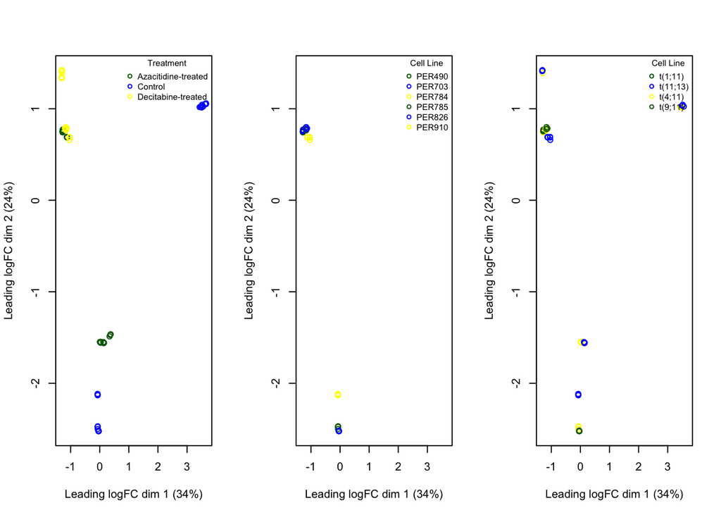

```r
# Set up the plotting window to have 4 plots in a single row
par(mfrow = c(1, 3))

# Now plot each MDS plot in turn, each will appear in its own slot
plotMDS(d, labels=NULL, pch=1, col=c("darkgreen","blue","yellow")[factor(luk_samples_dt$treatment)])
legend("topright", legend=levels(factor(luk_samples_dt$treatment)), pch=c(1), col=c("darkgreen","blue","yellow"), title="Treatment", bty='n', cex=0.75)


plotMDS(d, labels=NULL, pch=1, col=c("darkgreen","blue","yellow")[factor(luk_samples_dt$`cell line`)])
legend("topright", legend=levels(factor(luk_samples_dt$`cell line`)), pch=c(1), col=c("darkgreen","blue","yellow"), title="Cell Line", bty='n', cex=0.75)


plotMDS(d, labels=NULL, pch=1, col=c("darkgreen","blue","yellow")[factor(luk_samples_dt$genotype)])
legend("topright", legend=levels(factor(luk_samples_dt$genotype)), pch=c(1), col=c("darkgreen","blue","yellow"), title="Cell Line", bty='n', cex=0.75)
```

From the MDS plot created above, there was overlap between clustering of the treatment groups and cell lines. Using this, I choose one of the independent variables to be the treatment group. Notice that the genotype and cell line variables produce similar clustering, thus I chose cell line because the clustering seem to overlap with treatment more than genotype.

# Differential Gene Expression

```r
# Creating the model with the cell line and the treatment on the cells as the independent variables
model_design_pat <- model.matrix(~ luk_samples_dt$treatment + luk_samples_dt$`cell line`)
model_design_pat[1:5,1:5]
```

```
##   (Intercept) luk_samples_dt$treatmentControl
## 1           1                               1
## 2           1                               1
## 3           1                               1
## 4           1                               1
## 5           1                               1
##   luk_samples_dt$treatmentDecitabine-treated luk_samples_dt$`cell line`PER703
## 1                                          0                                0
## 2                                          0                                0
## 3                                          0                                0
## 4                                          0                                1
## 5                                          0                                1
##   luk_samples_dt$`cell line`PER784
## 1                                0
## 2                                0
## 3                                0
## 4                                0
## 5                                0
```

```r
# Estimating the dispersion
d = DGEList(counts=filtered_data_matrix, group=luk_samples_dt$treatment)
d <- estimateDisp(d, model_design_pat)
fit <- glmQLFit(d, model_design_pat)

# Perform the Quasi likelihood test
qlf.Azacitidine_vs_Decitabine <- glmQLFTest(fit, coef=3)

# Extract top hits
qlf_output_hits <- topTags(qlf.Azacitidine_vs_Decitabine, sort.by = "PValue", n = nrow(d))

# With the p-value set to be 0.05, determine how many were accepted after the test
length(which(qlf_output_hits$table$PValue < 0.05))
```

```
## [1] 6832
```

```r
length(qlf_output_hits$table$PValue)
```

```
## [1] 13721
```

```r
# With fdr correction, determine how many were accepted after the test
length(which(qlf_output_hits$table$FDR < 0.05))
```

```
## [1] 5907
```

Calculate p-values for each of the genes in your expression set. How many genes were significantly differentially expressed? What thresholds did you use and why?

Multiple hypothesis testing - correct your p-values using a multiple hypothesis correction method. Which method did you use? And Why? How many genes passed correction?

# Creating Volcano Plot

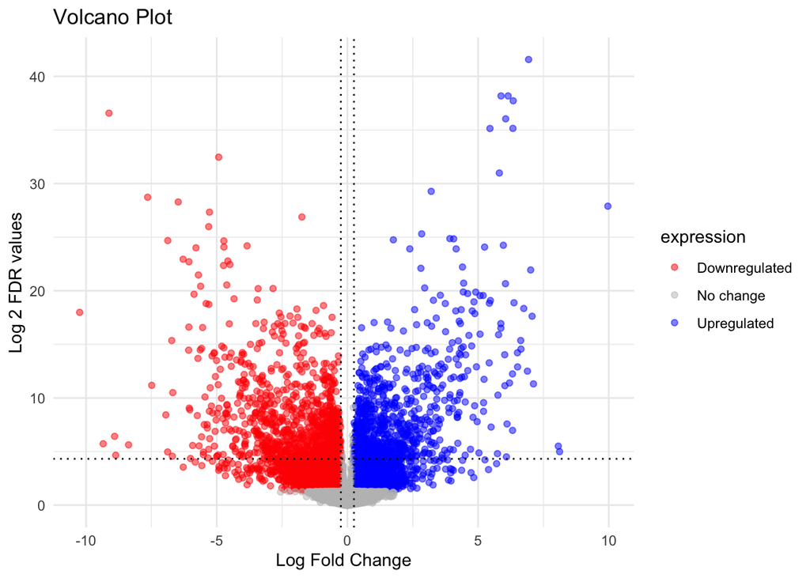

```r
results <- qlf_output_hits$table

# Create the important variables
results$logP <- -log10(results$FDR)
results <- results %>%
  mutate(expression = case_when(
    logFC > 0.25 & results$FDR < 0.05 ~ "Upregulated",
    logFC < -0.25 & results$FDR < 0.05 ~ "Downregulated",
    TRUE ~ "No change"
  ))

# Create the volcano plot
ggplot(results, aes(x = results$logFC, y = results$logP, color = expression)) +
  geom_point(alpha = 0.5) +
  scale_color_manual(values = c('red', 'grey', 'blue')) +
  theme_minimal() +
  labs(x = "Log Fold Change", y = "Log 2 FDR values", title = "Volcano Plot") +
  geom_vline(xintercept = c(-0.25, 0.25), linetype = "dotted") +
  geom_hline(yintercept = -log2(0.05), linetype = "dotted")
```

# Heatmap

```r
# Storing the top hits with an FDR value that is lesser than 0.05
top_hits <- rownames(qlf_output_hits$table)[qlf_output_hits$table$FDR < 0.05]

# Scale the top hits for the heatmap
heatmap_matrix_tophits <- t(
  scale(t(normalized_counts[which(rownames(normalized_counts) %in% top_hits),])))

# Determine the color scheme based on the values
if(min(heatmap_matrix_tophits) == 0){
  heatmap_col = colorRamp2(c( 0, max(heatmap_matrix_tophits)),
                           c( "white", "red"))
  } else {
    heatmap_col = colorRamp2(c(min(heatmap_matrix_tophits), 0,
                               max(heatmap_matrix_tophits)), c("blue", "white", "red"))
  }

# define colors for the different factors
unique_treatment <- unique(luk_samples_dt$treatment)
unique_treatmentcolors <- rainbow(n = length(unique_treatment))
names(unique_treatmentcolors) <- unique_treatment

unique_cellline <- unique(luk_samples_dt$'cell line')
unique_celllinecolors <- rainbow(n = length(unique_cellline))
names(unique_celllinecolors) <- unique_cellline

# Create the heatmap
ha_pat <- HeatmapAnnotation(df = data.frame(
  treatment = luk_samples_dt$treatment,
  cellline = luk_samples_dt$'cell line'),
  col = list(
    treatment = unique_treatmentcolors,
    cellline = unique_celllinecolors),
  show_legend = TRUE)
current_heatmap <- Heatmap(as.matrix(heatmap_matrix_tophits),
                           top_annotation = ha_pat,
                           cluster_rows = TRUE,cluster_columns = TRUE,show_row_dend = TRUE,
                           show_column_dend = TRUE, col=heatmap_col,show_column_names = FALSE,
                           show_row_names = FALSE,show_heatmap_legend = TRUE,
                           column_title = ("Top hits Treatment vs Cell line"))
# current_heatmap
```

# Thresholded overrepresentation analysis

```r
# Grouping genes
upregulatedids <- rownames(qlf_output_hits$table)[which(qlf_output_hits$table$FDR < 0.05 & qlf_output_hits$table$logFC > 0)]
downregulatedids <- rownames(qlf_output_hits$table)[which(qlf_output_hits$table$FDR < 0.05 & qlf_output_hits$table$logFC < 0)]
allids <- rownames(qlf_output_hits$table)

# Running G:profier
upregulated <- gost(query = upregulatedids,
                organism = "hsapiens", significant = FALSE, exclude_iea = TRUE,
                correction_method = "fdr",
                domain_scope = "annotated",
                numeric_ns = "", sources = c("GO:BP", "REAC", "WP"))

downregulated <- gost(query = downregulatedids,
                organism = "hsapiens", significant = FALSE, exclude_iea = TRUE,
                correction_method = "fdr",
                domain_scope = "annotated",
                numeric_ns = "", sources = c("GO:BP", "REAC", "WP"))

allgenes <- gost(query = allids,
                organism = "hsapiens", significant = FALSE, exclude_iea = TRUE,
                correction_method = "fdr",
                domain_scope = "annotated",
                numeric_ns = "", sources = c("GO:BP", "REAC", "WP"))

# Counting the number of genes in each group
num_up <- nrow(upregulated$result)
num_down <- nrow(downregulated$result)
num_allgenes <- nrow(allgenes$result)

# Filter based on term size
filtered_up <- upregulated $result[which(upregulated $result$term_size <= 250),]
filtered_down <- downregulated$result[which(downregulated$result$term_size <= 250),]
filtered_allgenes <- allgenes$result[which(allgenes$result$term_size <= 250),]
```

```r
# Renaming the columns for the table
colnames(filtered_up)[colnames(filtered_up) == "term_name"] <- "Term Name"
colnames(filtered_up)[colnames(filtered_up) == "p_value"] <- "P-value"
colnames(filtered_up)[colnames(filtered_up) == "term_size"] <- "Term Size"
colnames(filtered_up)[colnames(filtered_up) == "query_size"] <- "Query Size"

colnames(filtered_down)[colnames(filtered_down) == "term_name"] <- "Term Name"
colnames(filtered_down)[colnames(filtered_down) == "p_value"] <- "P-value"
colnames(filtered_down)[colnames(filtered_down) == "term_size"] <- "Term Size"
colnames(filtered_down)[colnames(filtered_down) == "query_size"] <- "Query Size"

colnames(filtered_allgenes)[colnames(filtered_allgenes) == "term_name"] <- "Term Name"
colnames(filtered_allgenes)[colnames(filtered_allgenes) == "p_value"] <- "P-value"
colnames(filtered_allgenes)[colnames(filtered_allgenes) == "term_size"] <- "Term Size"
colnames(filtered_allgenes)[colnames(filtered_allgenes) == "query_size"] <- "Query Size"

# Creating a visual for the table
kable(filtered_up[1:12, c("Term Name", "P-value", "Term Size", "Query Size")],
      caption = "Table 1: Top pathways for Upregulated Genes")
```

Table 1: Top pathways for Upregulated Genes

|  | Term Name | P-value | Term Size | Query Size |
| --- | --- | --- | --- | --- |
| 21 | mitochondrial gene expression | 0.0000129 | 157 | 2293 |
| 22 | mitochondrial translation | 0.0000187 | 127 | 2293 |
| 33 | ISG15-protein conjugation | 0.0019742 | 6 | 2293 |
| 37 | vesicle localization | 0.0040962 | 186 | 2293 |
| 40 | response to endoplasmic reticulum stress | 0.0051175 | 188 | 2293 |
| 41 | protein exit from endoplasmic reticulum | 0.0051341 | 46 | 2293 |
| 42 | establishment of vesicle localization | 0.0051341 | 178 | 2293 |
| 44 | establishment of protein localization to membrane | 0.0064564 | 238 | 2293 |
| 45 | retrograde protein transport, ER to cytosol | 0.0071381 | 28 | 2293 |
| 47 | endoplasmic reticulum to cytosol transport | 0.0071381 | 28 | 2293 |
| 53 | tRNA metabolic process | 0.0113202 | 185 | 2293 |
| 54 | maintenance of protein location in nucleus | 0.0129999 | 19 | 2293 |

```r
kable(filtered_down[1:12, c("Term Name", "P-value", "Term Size", "Query Size")],
      caption = "Table 2: Top pathways for Downregulated Genes")
```

Table 2: Top pathways for Downregulated Genes

|  | Term Name | P-value | Term Size | Query Size |
| --- | --- | --- | --- | --- |
| 91 | secondary alcohol biosynthetic process | 0.0009361 | 43 | 2311 |
| 92 | cholesterol biosynthetic process | 0.0009361 | 43 | 2311 |
| 106 | regulation of vasculature development | 0.0027215 | 241 | 2311 |
| 107 | regulation of angiogenesis | 0.0028173 | 236 | 2311 |
| 111 | sterol biosynthetic process | 0.0032957 | 47 | 2311 |
| 112 | type I interferon production | 0.0034409 | 110 | 2311 |
| 113 | regulation of type I interferon production | 0.0034409 | 110 | 2311 |
| 116 | regulation of telomerase RNA localization to Cajal body | 0.0038517 | 18 | 2311 |
| 117 | positive regulation of telomerase RNA localization to Cajal body | 0.0040747 | 15 | 2311 |
| 120 | negative regulation of cellular catabolic process | 0.0057561 | 184 | 2311 |
| 122 | RNA localization to Cajal body | 0.0063970 | 19 | 2311 |
| 127 | telomerase RNA localization to Cajal body | 0.0063970 | 19 | 2311 |

```r
kable(filtered_allgenes[1:12, c("Term Name", "P-value", "Term Size", "Query Size")],
      caption = "Table 3: Top pathways for All Genes")
```

Table 3: Top pathways for All Genes

|  | Term Name | P-value | Term Size | Query Size |
| --- | --- | --- | --- | --- |
| 118 | DNA replication | 0 | 227 | 10271 |
| 120 | regulation of chromosome organization | 0 | 240 | 10271 |
| 126 | mitochondrial gene expression | 0 | 157 | 10271 |
| 127 | sister chromatid segregation | 0 | 215 | 10271 |
| 135 | rRNA processing | 0 | 168 | 10271 |
| 137 | rRNA metabolic process | 0 | 205 | 10271 |
| 144 | tRNA metabolic process | 0 | 185 | 10271 |
| 152 | regulation of DNA repair | 0 | 208 | 10271 |
| 153 | DNA-templated DNA replication | 0 | 148 | 10271 |
| 156 | mitotic sister chromatid segregation | 0 | 176 | 10271 |
| 159 | mitochondrial translation | 0 | 127 | 10271 |
| 165 | mitotic nuclear division | 0 | 250 | 10271 |

Which method did you choose and why?

- I used the threshold method. I had thresholds for log fold change and FDR to group the unregulated and downregulated genes. I then placed the gene sets in g:Profiler to identify the top terms for each group(i.e unregulated, downregulated and all genes). I focused on the threshold method because this method seemed like it was most probable in identifying differentially expressed genes with minimized random chance involvement and heightened biological significance. I created the threshold for log fold change because I wanted to choose genes with highest probability of deferential expression. I also had a threshold for the FDR values as I wanted to limit the amount of false positives.

What annotation data did you use and why? What version of the annotation are you using?

- I used the Gene Ontology: Biological Process(GO:BP) (“The Gene Ontology (GO) Database and Informatics Resource” 2004), Reactome(REAC) (Fabregat et al. 2018), and WikiPathways(WP) (Kutmon et al. 2016) mainly because my research focuses on understanding the biological implications of the treatment on different cell lines of leukemic cells. I chose GO:BP because it focuses on biological processes that the genes might be involved in (“The Gene Ontology (GO) Database and Informatics Resource” 2004). I chose REAC and WP for in-depth analysis on the potential pathways and reactionsFabregat et al. (2018). I used the 2024-01-01 version for WP, 2024-01-25 version for REAC, and 2024-01-17 version for GO:BP. I found the versions by typing get_version_info() in the console.

How many genesets were returned with what thresholds?

- There were 10,934 gene sets returned for upregulated genes, 10,844 gene sets returned for downregulated genes, and 15,863 gene sets for all genes. All of them had the threshold value of 250 for the term size to identify the pathways with larger interpretative values.

Run the analysis using the up-regulated set of genes, and the down-regulated set of genes separately. How do these results compare to using the whole list (i.e all differentially expressed genes together vs. the up-regulated and down regulated differentially expressed genes separately)?

Present your results with the use of tables and screenshots. All figures should have appropriate figure legends. If using figures create a figures directory in your repo and make sure all references to the figures are relative in your Rmarkdown notebook.

- The tables are present above.

# Interpretation

Do the over-representation results support conclusions or mechanism discussed in the original paper?

Can you find evidence, i.e. publications, to support some of the results that you see. How does this evidence support your results.

# References

Davis, S. and Meltzer, P. S. GEOquery: a bridge between the Gene Expression Omnibus (GEO) and BioConductor. Bioinformatics, 2007, 14, 1846-1847

Gu, Z. (2016) Complex heatmaps reveal patterns and correlations in multidimensional genomic data. Bioinformatics.

Gu, Z. (2014) circlize implements and enhances circular visualization in R. Bioinformatics.

H. Wickham. ggplot2: Elegant Graphics for Data Analysis. Springer-Verlag New York, 2016.

Kolberg L, Raudvere U, Kuzmin I, Vilo J, Peterson H (2020). “gprofiler2- an R package for gene list functional enrichment analysis and namespace conversion toolset g:Profiler.” *F1000Research*, *9 (ELIXIR)*(709). R package version 0.2.3.

Morgan M, Ramos M (2023). *BiocManager: Access the Bioconductor Project Package Repository*. R package version 1.30.22, https://CRAN.R-project.org/package=BiocManager.

Robinson MD, McCarthy DJ and Smyth GK (2010). edgeR: a Bioconductor package for differential expression analysis of digital gene expression data. Bioinformatics 26, 139-140

Wickham H, François R, Henry L, Müller K, Vaughan D (2023). *dplyr: A Grammar of Data Manipulation*. R package version 1.1.3, https://CRAN.R-project.org/package=dplyr.

Xie Y (2023). *knitr: A General-Purpose Package for Dynamic Report Generation in R*. R package version 1.45, https://yihui.org/knitr/.

# Part 1: Non-thresholded Gene set Enrichment Analysis

```r
#path to GSEA jar
gsea_jar <- "../GSEA_4.3.3/gsea-cli.sh"
working_dir <- "data/"
output_dir <- "./generated_data/"
analysis_name <- "azacitidine_vs_decitabine"

#compute ranks
qlf_output_hits_withgn <- as.data.frame(qlf_output_hits)
qlf_output_hits_withgn$rank <- -log(qlf_output_hits_withgn$PValue, base = 10) * sign(qlf_output_hits_withgn$logFC)
qlf_output_hits_withgn <- qlf_output_hits_withgn[order(qlf_output_hits_withgn$rank), ]

#sort table by ranks
qlf_output_hits_withgn <- qlf_output_hits_withgn[order(qlf_output_hits_withgn$rank, decreasing = TRUE),]
qlf_output_hits_withgn$gene_name <- rownames(qlf_output_hits_withgn)
rank_file <- qlf_output_hits_withgn[, c("gene_name", "rank")]
# Write it to a .rnk file
write.table(rank_file, file = "./data/azacitvsdecit_RNASeq_ranks.rnk", sep = "\t", quote = FALSE, row.names = FALSE)
rnk_file <- "azacitvsdecit_RNASeq_ranks.rnk"

run_gsea <- FALSE
dest_gmt_file = file.path(output_dir, "Human_GOBP_AllPathways_noPFOCR_with_GO_iea_March_01_2024_symbol.gmt")

# Run GSEA
if(run_gsea){
  command <- paste("",gsea_jar,
                   "GSEAPreRanked -gmx", dest_gmt_file,
                   "-rnk" ,file.path(working_dir, rnk_file),
                   "-collapse false -nperm 1000 -scoring_scheme weighted",
                   "-rpt_label ",analysis_name,
                   "  -plot_top_x 20 -rnd_seed 12345  -set_max 200",
                   " -set_min 15 -zip_report false ",
                   " -out" ,output_dir,
                   " > gsea_output.txt",sep=" ")
  system(command)
}
```

1.) What method did you use? What genesets did you use? Make sure to specify versions and cite your methods.

- I used the GSEAPreRanked method that is part of the GSEA package Mootha et al. (2003). This method takes in a data file that already has the genes ranked (which is why it is named PreRanked). The ranking for each gene is based on the negative log of the P-value and sign of logFC value of azacitidine and decitabine.

The gene set I used was a .gmt file taken from the Bader lab labeled as “Human_GOBP_AllPathways_noPFOCR_with_GO_iea_March_01_2024_symbol.gmt”. Based on the title of these gene set, it is evident that the gene set pertains to humans. It contains Gene Ontology Biological Processes(GOBP) which can be used in identifying molecular functions. The keyword AllPathways suggests that all biological pathways are present.

The version of GSEA I used was 4.3.3. The version of the gene set I used was dated March 1, 2024.

2.) Summarize your enrichment results.

- Based on the results, there were 3089 gene sets that were up-regulated out of 5074. Out of the 3089 gene sets, only 421 gene sets had an FDR value of below 0.25. Identifying gene sets under this FDR value helps identify the pathways with stronger relevance. There were 257 genes set with p-value of less than 0.01 and 554 gene sets with p-value of 0.05. The up-regulated enrichment result stated LEUKOCYTE CHEMOTAXIS%GOBP%GO:0030595 as the top pathway. This pathway had an enrichment score of 0.79607016 which represents a significant over representation of this pathway compared to the other up-regulated genes. The FDR value received for this pathway is 0 which indicates that after correcting for multiple hypothesis testing, the significance is still high.
- In terms of the down regulated gene sets, 1985 out of 5074 gene sets were down regulated. Out of the 1985, only 89 gene sets were significantly enriched at FDR value of 0.25. Which means about 89 gene sets were most likely significantly down regulated after correcting for multiple hypothesis testing. 97 gene sets were significantly enriched at the pvalue of 0.01 and 260 gene sets are significantly enriched at pvalue of 0.05. The top pathway that was downregulated was PROTEINOGENIC AMINO ACID METABOLIC PROCESS%GOBP%GO:0170039 with the ES of -0.68892586. This suggests that there is a significant under representation of this pathway compared to the other down-regulated genes. This has a FDR value of 0.001806672 which suggests a high significance of this pathway to down-regulation.

3.) How do these results compare to the results from the thresholded analysis in Assignment #2. Compare qualitatively. Is this a straight forward comparison? Why or why not?

When comparing G:Profiler with GSEA, due to the methodologies and the gene sets used being different, I don’t think the comparison is very straightforward. That being said there are some aspects that are straight forward such as finding the general theme.

Now focusing on the complexities, G:Profiler and GSEA use different methods. G:Profiler looks at the overrepresentation of gene sets that is defined as upregulated or downregulated genes though a threshold value. But, GSEA does not use a threshold value and focuses on the enrichment value instead. This allows GSEA to examine genes without the needed to state if they are up or down regulated. Now focusing on the interpretation of the data, although the results might suggest an overall theme, the specific pathways vary. Like for example leukocyte chemotaxis implies recruitment of immune cells to a specific infected location but myeloid leukocyte activation indicates a general upregulation of immune cells activity.

# Part 2: Visualize your Gene set Enrichment Analysis in Cytoscape

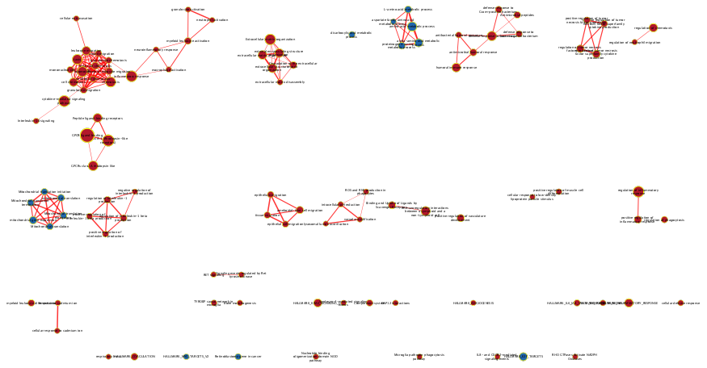

Enrichhment Map showing azacitidine vs decitabine

1.) Using your results from your non-thresholded gene set enrichment analysis visualize your results in Cytoscape. Create an enrichment map - how many nodes and how many edges in the resulting map? What thresholds were used to create this map? Make sure to record all thresholds. Include a screenshot of your network prior to manual layout.

- There are 74 nodes and 134 edges in the map. The threshold used for the node cut off was 0.05 and the edge cut of was 0.375. All the other parameters were set to default. The image above shows the map before any layout manipulation.

Nodes in the map represent gene sets. The node size represents the number of genes in the gene set and the edges represent overlap between gene sets. The thicker the edge, the higher the number of genes that overlap between the two nodes. The legend is red represents Azacitidine and blue represents Decitabine.

2.) Annotate your network - what parameters did you use to annotate the network. If you are using the default parameters make sure to list them as well.

[figure not shown]

Enrichhment Map showing azacitidine vs decitabine with grouped gene sets

For the creation of the clustered image, I used the default parameters present. The clustering algorithm used is MCL Clustering with the edge weight option as similarity_coefficeint. The max word per labels were 3 and the min word label was 1. The adjacent word bonus was set to 8. In addition, I clicked on the “Publication-Ready” option so that question 3 is completed.

3.) Make a publication ready figure - include this figure with proper legends in your notebook.

- Attached in the second image

4.) Collapse your network to a theme network. What are the major themes present in this analysis? Do they fit with the model? Are there any novel pathways or themes?

[figure not shown]

Theme network

- The major theme present in this network are chemotaxis neurophil migration, organization extracurricular matrix and mitochondrial gene translation. These pathways do fit the model as these pathways seem to have a large overlap in the general theme of increased immune response and decresed DNA replication.

Some of the pathways are upregulated and others are down regulated. There are some novel pathways such as organization extracurricular matrix and mitochondrial gene translation but there are some old pathways too such as chemotaxis neurophil migration. There are some pathways which are very similar on the clustered table versus the theme network. For example, tissue migration epithelial is present in the clustered pathway network meanwhile tissue migration amebodial is present in the theme network. Both of them are very similar to each other but they do have a notable difference. Overall there seems to be a large overlap between the pathways in the clustered network and the theme network which shows a promising fit within the model.

# Interpretation and detailed view of results

1.) Do the enrichment results support conclusions or mechanism discussed in the original paper? How do these results differ from the results you got from Assignment #2 thresholded methods

- In the enrichment analysis, it was found that amino acid metabolic processes were downregulated, whereas pathways related to leukocyte chemotaxis were significantly upregulated. These findings support the original paper’s discussion of how azacitidine and decitabine could boost immune response and affect gene expression in KMT2A-rearranged infant ALL(Cheung et al. 2023b). The pathways outputted from GSEA support the hypothesis noted in the paper and suggest the drugs could potentially reactivate tumor suppressor genes.

This follows the studies that note that the mechanisms followed by azacitidine and decitabine might exert therapeutic effects(Cheung et al. 2023b). The results from the assignment suggest that these drugs may have a complex impact on leukemia cells as supported by the study(Cheung et al. 2023b). The drugs might possibly affect interactions between tumor microenvironment and cellular metabolism(Cheung et al. 2023b).

2.) Can you find evidence, i.e. publications, to support some of the results that you see. How does this evidence support your result?

- There are many publications online that suggest the use of azacitidine and decitabine for therapeutic uses in the domain of ALL(Hong et al. 2021). It was noted in a study that upregulating leukocyte chemotaxis pathways would enhance the immune system’s ability to combat leukemia(Hong et al. 2021). A significant role is played by the immune response in controlling and eliminating cancer cells(Hong et al. 2021). In the context of leukemia treatment, these pathways might also be crucial for mobilizing immune cells against cancerous cells in order to improve immune function(Hong et al. 2021).

By affecting leukemia cell’s metabolic and replicative capacities, azacitidine and decitabine might impair their proliferation and survival(Venugopal et al. 2022). As discussed in this paper, targeting DNA replication stress may be an effective strategy in the treatment of cancer(Venugopal et al. 2022). According to your enrichment analysis, this study demonstrates how DNA replication pathways are essential for cancer cell survival and proliferation(Venugopal et al. 2022).

The aim of this review is to explain how metabolic pathways can affect immunity by interfering with amino acid metabolism(Tabe, Lorenzi, and Konopleva 2019). The downregulation of amino acid metabolic suggests lower survival rate of leukemia cells aligning with the results produced by examining azacitidine and decitabine(Tabe, Lorenzi, and Konopleva 2019).

# Dark Matter

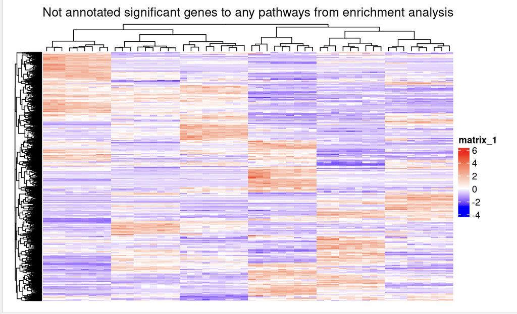

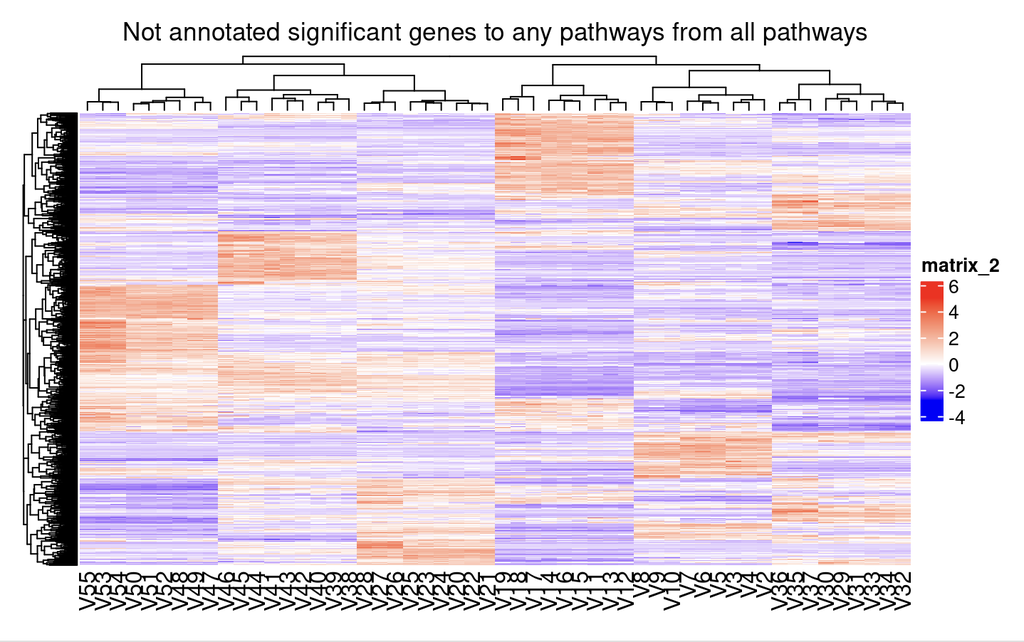

```r
# Include a heatmap of any significant genes that are not annotated to any of the pathways returned in the enrichment analysis.

library(GSA)
gmt_file <- file.path(getwd(),"generated_data", "Human_GOBP_AllPathways_noPFOCR_with_GO_iea_March_01_2024_symbol.gmt")
capture.output(genesets<- GSA.read.gmt(gmt_file),file="gsa_load.out")
names(genesets$genesets) <- genesets$geneset.names

expression <- read.table("./data/GSE212591_tmm_counts.txt", stringsAsFactors=FALSE)

ranks <- read.table(file.path(getwd(),"data","azacitvsdecit_RNASeq_ranks.rnk"),
                    header = TRUE, sep = "\t", quote="\"",
                    stringsAsFactors = FALSE)

gsea_directories <- list.files(path = file.path(getwd(),"generated_data"), pattern = "\\.GseaPreranked")

if(length(gsea_directories) == 1){
  gsea_dir <- file.path(getwd(),"generated_data",gsea_directories[1])
  #get the gsea result files
  gsea_results_files <- list.files(path = gsea_dir,
                                   pattern = "gsea_report_*.*.tsv")
  #there should be 2 gsea results files
  enr_file1 <- read.table(file.path(gsea_dir,gsea_results_files[1]),
                          header = TRUE, sep = "\t", quote="\"",
                          stringsAsFactors = FALSE,row.names=1)
  enr_file2 <- read.table(file.path(gsea_dir,gsea_results_files[1]),
                          header = TRUE, sep = "\t", quote="\"",
                          stringsAsFactors = FALSE,row.names=1)
}

#get the genes from the set of enriched pathways (all threshold)
all_enr_genesets<- c(rownames(enr_file1), rownames(enr_file2))
genes_enr_gs <- c()
for(i in 1:length(all_enr_genesets)){
  current_geneset <- unlist(genesets$genesets[which(genesets$geneset.names %in% all_enr_genesets[i])])
  genes_enr_gs <- union(genes_enr_gs, current_geneset)
}

FDR_threshold <- 0.05
#get the genes from the set of enriched pathwasy (no matter what thre
all_sig_enr_genesets <- c(rownames(enr_file1)[which(enr_file1[,"FDR.q.val"] <= FDR_threshold)])
genes_sig_enr_gs <- c()

for(i in 1:length(all_sig_enr_genesets)){
  current_geneset <- unlist(genesets$genesets[which(genesets$geneset.names %in% all_sig_enr_genesets[i])])
  genes_sig_enr_gs <- union(genes_sig_enr_gs, current_geneset)
}

genes_all_gs <- unique(unlist(genesets$genesets))
diff_genes <- rownames(qlf_output_hits[qlf_output_hits$table$FDR <= 0.1, ])

# Heatmap
dark_matter_genes <- setdiff(diff_genes, genes_enr_gs)
rownames(expression) <- expression$V1
expression <- expression[, -1]
expression_subset_enriched <- expression[dark_matter_genes, ]
expression_subset_enriched_matrix <- as.matrix(expression_subset_enriched)
expression_subset_enriched_matrix <- apply(expression_subset_enriched_matrix, 2, as.numeric)

enrichment_matrix <- t(scale(t(expression_subset_enriched_matrix)))

if(min(enrichment_matrix) == 0){
  heatmap_col = colorRamp2(c( 0, max(enrichment_matrix)),
                           c( "white", "red"))
  } else {
    heatmap_col = colorRamp2(c(min(enrichment_matrix), 0,
                               max(enrichment_matrix)), c("blue", "white", "red"))
    }

enrichment_heatmap <- Heatmap(as.matrix(enrichment_matrix),
                           cluster_rows = TRUE,
                           cluster_columns = TRUE,
                           show_row_dend = TRUE,
                           show_column_dend = TRUE,
                           col=heatmap_col,
                           show_column_names = FALSE,
                           show_row_names = FALSE,
                           show_heatmap_legend = TRUE,
                           column_title =("Not annotated significant genes to any pathways from enrichment analysis"))


# enrichment_heatmap
# My Mac doesn't allow the loading of a heatmap so I used the online UOFT R server to load the heat map and attached a screen shot here

# All pathways
dark_matter_genes_all <- setdiff(diff_genes, genes_all_gs)
expression_subset_all <- expression[dark_matter_genes_all, ]
expression_subset_all_matrix <- as.matrix(expression_subset_all)
expression_subset_all_matrix <- apply(expression_subset_all_matrix, 2, as.numeric)
standardized_matrix_all <- t(scale(t(expression_subset_all_matrix)))

if(min(standardized_matrix_all) == 0){
  heatmap_col = colorRamp2(c( 0, max(standardized_matrix_all)),
                           c( "white", "red"))
  } else {
    heatmap_col = colorRamp2(c(min(standardized_matrix_all), 0,
                               max(standardized_matrix_all)), c("blue", "white", "red"))
    }


all_heatmap <- Heatmap(as.matrix(standardized_matrix_all),
                           show_row_dend = TRUE,show_column_dend = TRUE,
                           col=heatmap_col,show_column_names = TRUE,
                           show_row_names = FALSE,show_heatmap_legend = TRUE,
                           column_title =("Not annotated significant genes to any pathways from all pathways"))
# all_heatmap
# My Mac doesn't allow the loading of a heatmap so I used the online UOFT R server to load the heat map and attached a screen shot here
```

In the heat map created by examining annotated significant genes to any pathways from enrichment analysis, “CSF3R” was one of the genes present which is part of familial chronic neutrophilic leukemia receptor(Maxson Julia E. et al. 2013). The Colony Stimulating Factor 3 Receptor is a critical component of the immune system and regulates granulocytes in the blood(Maxson Julia E. et al. 2013). The heatmap clusters based on the cell lines as it is evident that there is partition. CSF3R is not included in any of the gene sets but has is differential expressed. This is interesting to note as this might suggest that the durgs(i.e Azacitidine and decitabine) affect the chronic neutrophilic leukemia receptor in addition to the other aspects of the immune defense system.

In the second heatmap created, CD4 is differentially expressed and is not annotated. CD4 is primarily responsible for human defensive mechanisms by recruiting immune cells such as lymphocytes(Khan n.d.). Dendritic cells, monocytes, macrophages, and T helper cells contain CD4 glycoprotein on their surfaces (Khan n.d.). By recognizing antigens presented by MHC class II molecules, it facilitates the activation of T helper cells in the immune system (Khan n.d.). Thus, this might suggest that Azacitidine and decitabine primarily target immuno cells receptors. In addition, the heat map suggest that there are biological conditions in the individuals which cause the expression to differ drastically.

# References

Davis, S. and Meltzer, P. S. GEOquery: a bridge between the Gene Expression Omnibus (GEO) and BioConductor. Bioinformatics, 2007, 14, 1846-1847

Gu, Z. (2016) Complex heatmaps reveal patterns and correlations in multidimensional genomic data. Bioinformatics.

Gu, Z. (2014) circlize implements and enhances circular visualization in R. Bioinformatics.

Morgan M, Ramos M (2023). BiocManager: Access the Bioconductor Project Package Repository. R package version 1.30.22, https://CRAN.R-project.org/package=BiocManager.

Robinson MD, McCarthy DJ and Smyth GK (2010). edgeR: a Bioconductor package for differential expression analysis of digital gene expression data. Bioinformatics 26, 139-140

Wickham H, François R, Henry L, Müller K, Vaughan D (2023). dplyr: A Grammar of Data Manipulation. R package version 1.1.3, https://CRAN.R-project.org/package=dplyr.

Xie Y (2023). knitr: A General-Purpose Package for Dynamic Report Generation in R. R package version 1.45, https://yihui.org/knitr/.

Cheung, Laurence C., Carlos Aya-Bonilla, Mark N. Cruickshank, Sung K. Chiu, Vincent Kuek, Denise Anderson, Grace-Alyssa Chua, et al. 2023a. “Preclinical Efficacy of Azacitidine and Venetoclax for Infant KMT2A-Rearranged Acute Lymphoblastic Leukemia Reveals a New Therapeutic Strategy.” *Leukemia* 37 (1): 61. https://doi.org/10.1038/s41375-022-01746-3.

———, et al. 2023b. “Preclinical Efficacy of Azacitidine and Venetoclax for Infant KMT2A-Rearranged Acute Lymphoblastic Leukemia Reveals a New Therapeutic Strategy.” *Leukemia* 37 (1): 61–71. https://doi.org/10.1038/s41375-022-01746-3.

Fabregat, Antonio, Steven Jupe, Lisa Matthews, Konstantinos Sidiropoulos, Marc Gillespie, Phani Garapati, Robin Haw, et al. 2018. “The Reactome Pathway Knowledgebase.” *Nucleic Acids Research* 46 (Database issue): D649–55. https://doi.org/10.1093/nar/gkx1132.

Hong, Zixi, Zimeng Wei, Tian Xie, Lin Fu, Jiaxing Sun, Fuling Zhou, Muhammad Jamal, Qiuping Zhang, and Liang Shao. 2021. “Targeting Chemokines for Acute Lymphoblastic Leukemia Therapy.” *Journal of Hematology & Oncology* 14 (March): 48. https://doi.org/10.1186/s13045-021-01060-y.

Khan, Naazneen. n.d. “Comparative and Evolutionary Insights into CD4 Gene Across Mammalian and Avian Taxa.” *Interventional Medicine & Applied Science* 7 (4): 152–60. Accessed April 2, 2024. https://doi.org/10.1556/1646.7.2015.4.4.

Kutmon, Martina, Anders Riutta, Nuno Nunes, Kristina Hanspers, Egon L. Willighagen, Anwesha Bohler, Jonathan Mélius, et al. 2016. “WikiPathways: Capturing the Full Diversity of Pathway Knowledge.” *Nucleic Acids Research* 44 (Database issue): D488–94. https://doi.org/10.1093/nar/gkv1024.

Li, Wentian. 2012. “Volcano Plots in Analyzing Differential Expressions with mRNA Microarrays.” *Journal of Bioinformatics and Computational Biology* 10 (6): 1231003. https://doi.org/10.1142/S0219720012310038.

Maxson Julia E., Gotlib Jason, Pollyea Daniel A., Fleischman Angela G., Agarwal Anupriya, Eide Christopher A., Bottomly Daniel, et al. 2013. “Oncogenic CSF3R Mutations in Chronic Neutrophilic Leukemia and Atypical CML.” *New England Journal of Medicine* 368 (19): 1781–90. https://doi.org/10.1056/NEJMoa1214514.

Mootha, Vamsi K., Cecilia M. Lindgren, Karl-Fredrik Eriksson, Aravind Subramanian, Smita Sihag, Joseph Lehar, Pere Puigserver, et al. 2003. “PGC-1α-Responsive Genes Involved in Oxidative Phosphorylation Are Coordinately Downregulated in Human Diabetes.” *Nature Genetics* 34 (3): 267–73. https://doi.org/10.1038/ng1180.

Moreno Vanegas, Yenny, and Talha Badar. 2022. “Clinical Utility of Azacitidine in the Management of Acute Myeloid Leukemia: Update on Patient Selection and Reported Outcomes.” *Cancer Management and Research* 14 (December): 3527–38. https://doi.org/10.2147/CMAR.S271442.

Santini, Valeria, Michael Lübbert, Agnieszka Wierzbowska, and Gert J. Ossenkoppele. 2022. “The Clinical Value of Decitabine Monotherapy in Patients with Acute Myeloid Leukemia.” *Advances in Therapy* 39 (4): 1474–88. https://doi.org/10.1007/s12325-021-01948-8.

Subramanian, Aravind, Pablo Tamayo, Vamsi K. Mootha, Sayan Mukherjee, Benjamin L. Ebert, Michael A. Gillette, Amanda Paulovich, et al. 2005. “Gene Set Enrichment Analysis: A Knowledge-Based Approach for Interpreting Genome-Wide Expression Profiles.” *Proceedings of the National Academy of Sciences* 102 (43): 15545–50. https://doi.org/10.1073/pnas.0506580102.

Tabe, Yoko, Philip L. Lorenzi, and Marina Konopleva. 2019. “Amino Acid Metabolism in Hematologic Malignancies and the Era of Targeted Therapy.” *Blood* 134 (13): 1014–23. https://doi.org/10.1182/blood.2019001034.

“The Gene Ontology (GO) Database and Informatics Resource.” 2004. *Nucleic Acids Research* 32 (Database issue): D258–61. https://doi.org/10.1093/nar/gkh036.

Venugopal, Kartika, Yang Feng, Pawel Nowialis, Huanzhou Xu, Daniil E. Shabashvili, Cassandra M. Berntsen, Prabhjot Kaur, et al. 2022. “DNMT3A Harboring Leukemia-Associated Mutations Directs Sensitivity to DNA Damage at Replication Forks.” *Clinical Cancer Research: An Official Journal of the American Association for Cancer Research* 28 (4): 756–69. https://doi.org/10.1158/1078-0432.CCR-21-2863.